# Extracting road networks from OSM

Elsa Arcaute, Carlos Molinero and Mateo Neira, CASA, UCL

Created in 2015 by Carlos Molinero, last update 24/02/2020

# Setting up: Install the following packages if you don’t have them already

```r
install.packages(c("igraph","ggplot2","rgdal","rgeos","geosphere"))
```

You only need to install these once, the next time that you will open R, the packages will be installed and you just need to call them as follows:

```r
library(igraph)
library(rgdal)
library(rgeos)
library(ggplot2)
library(geosphere)
```

# Extracting a map from OSM

There is a very good package available in Python that you can use instead to extract the road networks using the procedure defined below. The package is called osmx and was developed by Geoff Boeing: https://github.com/gboeing.

If you do not use python, you could still do it in R as follows. First extract the street networks from the following website: http://extract.bbbike.org. Since maps can come in many different formats, you need to be careful in extracting it in the right format. This needs to be “Shapefile (Esri)”. After selecting the region of interest, you need to wait 5-7mins before receiving the file via email. To speed things up, I have extracted the road network for you for this session, it is inside the directory “Central_London_Shapefile”.

Let us read the shapefile downloaded from OSM:

```r
folderSpatialData="Central_London_Shapefile/shape/"
shapeFile <- readOGR(dsn = folderSpatialData, "roads")
```

For Windows users, note that you need to remove the last /, i.e. folderSpatialData=“data/Oxford_Shapefile/shape”

Let us see some of the features, such as the lines, which are given as a series of connected points. You will notice that each line has an id and a series of coordinates for the points. To look at the first lines of your data in R you can use the head() command and select the feature:

```r
head(shapeFile@lines)
```

```
## [[1]]
## An object of class "Lines"
## Slot "Lines":
## [[1]]
## An object of class "Line"
## Slot "coords":
##           [,1]     [,2]
##  [1,] -0.13493 51.52456
##  [2,] -0.13500 51.52453
##  [3,] -0.13576 51.52426
##  [4,] -0.13582 51.52423
##  [5,] -0.13596 51.52417
##  [6,] -0.13631 51.52403
##  [7,] -0.13706 51.52376
##  [8,] -0.13709 51.52375
##  [9,] -0.13724 51.52369
##
##
##
## Slot "ID":
## [1] "0"
##
##
## [[2]]
## An object of class "Lines"
## Slot "Lines":
## [[1]]
## An object of class "Line"
## Slot "coords":
##          [,1]     [,2]
## [1,] -0.13037 51.51640
## [2,] -0.13038 51.51646
## [3,] -0.13040 51.51651
## [4,] -0.13047 51.51663
## [5,] -0.13055 51.51678
## [6,] -0.13065 51.51691
## [7,] -0.13080 51.51706
##
##
##
```

[output cut: 75 more lines]

```
## Slot "coords":
##          [,1]     [,2]
## [1,] -0.12728 51.50838
## [2,] -0.12728 51.50845
## [3,] -0.12728 51.50848
## [4,] -0.12729 51.50852
## [5,] -0.12729 51.50854
## [6,] -0.12728 51.50856
## [7,] -0.12725 51.50857
## [8,] -0.12717 51.50857
##
##
##
## Slot "ID":
## [1] "5"
```

To get an idea of the sort of data stored

```r
head(shapeFile@data)
```

```
##    osm_id                 name  ref     type oneway bridge maxspeed
## 0   31030          Grafton Way A400    trunk      1      0       20
## 1   31039 Tottenham Court Road A400  primary      1      0       30
## 2   31959     Cleveland Street <NA> tertiary      1      0       30
## 3 2190803              Aldwych   A4  primary      1      0       30
## 4 2191122          Euston Road A501    trunk      1      0       30
## 5 2198814                 <NA> <NA> tertiary      1      0       30
##     LENGTH
## 0 0.002469
## 1 0.000800
## 2 0.000953
## 3 0.002177
## 4 0.000795
## 5 0.000295
```

Let us now convert it into a data frame

```r
shapeFile.f=fortify(shapeFile)
head(shapeFile.f)
```

```
##       long      lat order piece id group
## 1 -0.13493 51.52456     1     1  0   0.1
## 2 -0.13500 51.52453     2     1  0   0.1
## 3 -0.13576 51.52426     3     1  0   0.1
## 4 -0.13582 51.52423     4     1  0   0.1
## 5 -0.13596 51.52417     5     1  0   0.1
## 6 -0.13631 51.52403     6     1  0   0.1
```

Let us construct the list of connecting nodes for the network

```r
shapeFile.f.postOrder=shapeFile.f[2:nrow(shapeFile.f),c("long","lat","id")]
shapeFile.f.postOrder=rbind(shapeFile.f.postOrder,shapeFile.f[1,c("long","lat","id")])
head(shapeFile.f.postOrder)
```

```
##       long      lat id
## 2 -0.13500 51.52453  0
## 3 -0.13576 51.52426  0
## 4 -0.13582 51.52423  0
## 5 -0.13596 51.52417  0
## 6 -0.13631 51.52403  0
## 7 -0.13706 51.52376  0
```

```r
shapeFile.f.segments=data.frame(idA=shapeFile.f$id,idB=shapeFile.f.postOrder$id,longA=shapeFile.f$long,latA=shapeFile.f$lat,longB=shapeFile.f.postOrder$long,latB=shapeFile.f.postOrder$lat)

dim(shapeFile.f.segments)
```

```
## [1] 16031     6
```

```r
shapeFile.f.segments[1:20,]
```

```
##    idA idB    longA     latA    longB     latB
## 1    0   0 -0.13493 51.52456 -0.13500 51.52453
## 2    0   0 -0.13500 51.52453 -0.13576 51.52426
## 3    0   0 -0.13576 51.52426 -0.13582 51.52423
## 4    0   0 -0.13582 51.52423 -0.13596 51.52417
## 5    0   0 -0.13596 51.52417 -0.13631 51.52403
## 6    0   0 -0.13631 51.52403 -0.13706 51.52376
## 7    0   0 -0.13706 51.52376 -0.13709 51.52375
## 8    0   0 -0.13709 51.52375 -0.13724 51.52369
## 9    0   1 -0.13724 51.52369 -0.13037 51.51640
## 10   1   1 -0.13037 51.51640 -0.13038 51.51646
## 11   1   1 -0.13038 51.51646 -0.13040 51.51651
## 12   1   1 -0.13040 51.51651 -0.13047 51.51663
## 13   1   1 -0.13047 51.51663 -0.13055 51.51678
## 14   1   1 -0.13055 51.51678 -0.13065 51.51691
## 15   1   1 -0.13065 51.51691 -0.13080 51.51706
## 16   1   2 -0.13080 51.51706 -0.13911 51.52082
## 17   2   2 -0.13911 51.52082 -0.13920 51.52089
## 18   2   2 -0.13920 51.52089 -0.13937 51.52103
## 19   2   2 -0.13937 51.52103 -0.13985 51.52142
## 20   2   3 -0.13985 51.52142 -0.11922 51.51136
```

Now let us remove the links between nodes that are not part of the same segment. That is, that have different idA and idB

```r
shapeFile.f.segments=shapeFile.f.segments[shapeFile.f.segments$idA==shapeFile.f.segments$idB,]
dim(shapeFile.f.segments)
```

```
## [1] 12449     6
```

```r
shapeFile.f.segments[1:20,]
```

```
##    idA idB    longA     latA    longB     latB
## 1    0   0 -0.13493 51.52456 -0.13500 51.52453
## 2    0   0 -0.13500 51.52453 -0.13576 51.52426
## 3    0   0 -0.13576 51.52426 -0.13582 51.52423
## 4    0   0 -0.13582 51.52423 -0.13596 51.52417
## 5    0   0 -0.13596 51.52417 -0.13631 51.52403
## 6    0   0 -0.13631 51.52403 -0.13706 51.52376
## 7    0   0 -0.13706 51.52376 -0.13709 51.52375
## 8    0   0 -0.13709 51.52375 -0.13724 51.52369
## 10   1   1 -0.13037 51.51640 -0.13038 51.51646
## 11   1   1 -0.13038 51.51646 -0.13040 51.51651
## 12   1   1 -0.13040 51.51651 -0.13047 51.51663
## 13   1   1 -0.13047 51.51663 -0.13055 51.51678
## 14   1   1 -0.13055 51.51678 -0.13065 51.51691
## 15   1   1 -0.13065 51.51691 -0.13080 51.51706
## 17   2   2 -0.13911 51.52082 -0.13920 51.52089
## 18   2   2 -0.13920 51.52089 -0.13937 51.52103
## 19   2   2 -0.13937 51.52103 -0.13985 51.52142
## 21   3   3 -0.11922 51.51136 -0.11915 51.51141
## 22   3   3 -0.11915 51.51141 -0.11909 51.51147
## 23   3   3 -0.11909 51.51147 -0.11904 51.51154
```

In the following let us rename columns and do some manipulations simply to assign unique ids to the points. You can look closely at the commands at home:

```r
coordinatesSegments=shapeFile.f.segments[,c("longA","latA","longB","latB")]
colnames(coordinatesSegments)[colnames(coordinatesSegments)=="longA"]="x1"
colnames(coordinatesSegments)[colnames(coordinatesSegments)=="latA"]="y1"
colnames(coordinatesSegments)[colnames(coordinatesSegments)=="longB"]="x2"
colnames(coordinatesSegments)[colnames(coordinatesSegments)=="latB"]="y2"

head(coordinatesSegments)
```

```
##         x1       y1       x2       y2
## 1 -0.13493 51.52456 -0.13500 51.52453
## 2 -0.13500 51.52453 -0.13576 51.52426
## 3 -0.13576 51.52426 -0.13582 51.52423
## 4 -0.13582 51.52423 -0.13596 51.52417
## 5 -0.13596 51.52417 -0.13631 51.52403
## 6 -0.13631 51.52403 -0.13706 51.52376
```

```r
pointsA=coordinatesSegments[,c("x1","y1")]
pointsB=coordinatesSegments[,c("x2","y2")]

colnames(pointsA)[1]="x"
colnames(pointsA)[2]="y"

colnames(pointsB)=colnames(pointsA)
```

let us now assign an individual id to each of the points

```r
points=rbind(pointsA,pointsB)
dim(points)
```

```
## [1] 24898     2
```

```r
#many are repeated
points=unique(points)
dim(points)
```

```
## [1] 10548     2
```

```r
points=data.frame(id=1:nrow(points),points)
head(points)
```

```
##   id        x        y
## 1  1 -0.13493 51.52456
## 2  2 -0.13500 51.52453
## 3  3 -0.13576 51.52426
## 4  4 -0.13582 51.52423
## 5  5 -0.13596 51.52417
## 6  6 -0.13631 51.52403
```

Now that we have the ids for the points we can create a list for the network in the usual format: Node1 Node2. We start by assigning the id to all Nodes 1

```r
segments=merge(coordinatesSegments,points,by.x=c("x1","y1"),by.y=c("x","y"))
head(segments)
```

```
##         x1       y1       x2       y2   id
## 1 -0.11502 51.50517 -0.11510 51.50519 6227
## 2 -0.11502 51.50607 -0.11553 51.50579 6196
## 3 -0.11502 51.50610 -0.11502 51.50613 2759
## 4 -0.11502 51.50613 -0.11504 51.50613 2760
## 5 -0.11502 51.52283 -0.11613 51.52407  258
## 6 -0.11503 51.51352 -0.11545 51.51363 2754
```

```r
colnames(segments)[colnames(segments)=="id"]="idNode1"

head(segments)
```

```
##         x1       y1       x2       y2 idNode1
## 1 -0.11502 51.50517 -0.11510 51.50519    6227
## 2 -0.11502 51.50607 -0.11553 51.50579    6196
## 3 -0.11502 51.50610 -0.11502 51.50613    2759
## 4 -0.11502 51.50613 -0.11504 51.50613    2760
## 5 -0.11502 51.52283 -0.11613 51.52407     258
## 6 -0.11503 51.51352 -0.11545 51.51363    2754
```

Now to all Nodes2:

```r
segments=merge(segments,points,by.x=c("x2","y2"),by.y=c("x","y"))

head(segments)
```

```
##         x2       y2       x1       y1 idNode1    id
## 1 -0.11502 51.50517 -0.11505 51.50529    6226  6227
## 2 -0.11502 51.50607 -0.11506 51.50612    6195  6196
## 3 -0.11502 51.50610 -0.11504 51.50611    2758  2759
## 4 -0.11502 51.50613 -0.11502 51.50610    2759  2760
## 5 -0.11502 51.51874 -0.11508 51.51888    1292 10177
## 6 -0.11502 51.52283 -0.11574 51.52281    2500   258
```

```r
colnames(segments)[colnames(segments)=="id"]="idNode2"

head(segments)
```

```
##         x2       y2       x1       y1 idNode1 idNode2
## 1 -0.11502 51.50517 -0.11505 51.50529    6226    6227
## 2 -0.11502 51.50607 -0.11506 51.50612    6195    6196
## 3 -0.11502 51.50610 -0.11504 51.50611    2758    2759
## 4 -0.11502 51.50613 -0.11502 51.50610    2759    2760
## 5 -0.11502 51.51874 -0.11508 51.51888    1292   10177
## 6 -0.11502 51.52283 -0.11574 51.52281    2500     258
```

If we want the distance between the points, that is, in order to compute the length of the street, we need to either project the points which are in lat long or we need to compute the distance in the ellipsoid. Let us do the latter using a function constructed for this: distGeo

```r
p1=data.frame(segments$x1,segments$y1)
p2=data.frame(segments$x2,segments$y2)
head(p2)
```

```
##   segments.x2 segments.y2
## 1    -0.11502    51.50517
## 2    -0.11502    51.50607
## 3    -0.11502    51.50610
## 4    -0.11502    51.50613
## 5    -0.11502    51.51874
## 6    -0.11502    51.52283
```

```r
distance=distGeo(p1,p2)
```

Let us assign a new field to the segments: the distance

```r
segments=data.frame(segments,distance=distance)
head(segments)
```

```
##         x2       y2       x1       y1 idNode1 idNode2  distance
## 1 -0.11502 51.50517 -0.11505 51.50529    6226    6227 13.512465
## 2 -0.11502 51.50607 -0.11506 51.50612    6195    6196  6.217632
## 3 -0.11502 51.50610 -0.11504 51.50611    2758    2759  1.779357
## 4 -0.11502 51.50613 -0.11502 51.50610    2759    2760  3.337739
## 5 -0.11502 51.51874 -0.11508 51.51888    1292   10177 16.123313
## 6 -0.11502 51.52283 -0.11574 51.52281    2500     258 50.021716
```

```r
segments=segments[distance>0,]
```

Finally we can construct the network

```r
ncol=data.frame(idNode1=segments$idNode1,idNode2=segments$idNode2,weight=segments$distance)

head(ncol)
```

```
##   idNode1 idNode2    weight
## 1    6226    6227 13.512465
## 2    6195    6196  6.217632
## 3    2758    2759  1.779357
## 4    2759    2760  3.337739
## 5    1292   10177 16.123313
## 6    2500     258 50.021716
```

Now that we have created a network, let us save it as a list

```r
dir.create("data")
file_out <- paste0('data/London_network.txt')
write.table(ncol, file = file_out, row.names=FALSE,col.names=T,sep=" ")
```

# Computations on the street network

Let us define the graph using the format above

```r
G_all=graph.data.frame(ncol,directed=F)
```

To look at the properties of the graph

```r
summary(G_all)
```

```
## IGRAPH 65206b0 UNW- 10548 12449 --
## + attr: name (v/c), weight (e/n)
```

To look at the edges and vertices, simply type E(G) and V(G). To obtain an edge list type:

```r
head(get.edgelist(G_all))
```

```
##      [,1]   [,2]
## [1,] "6226" "6227"
## [2,] "6195" "6196"
## [3,] "2758" "2759"
## [4,] "2759" "2760"
## [5,] "1292" "10177"
## [6,] "2500" "258"
```

Let us plot it

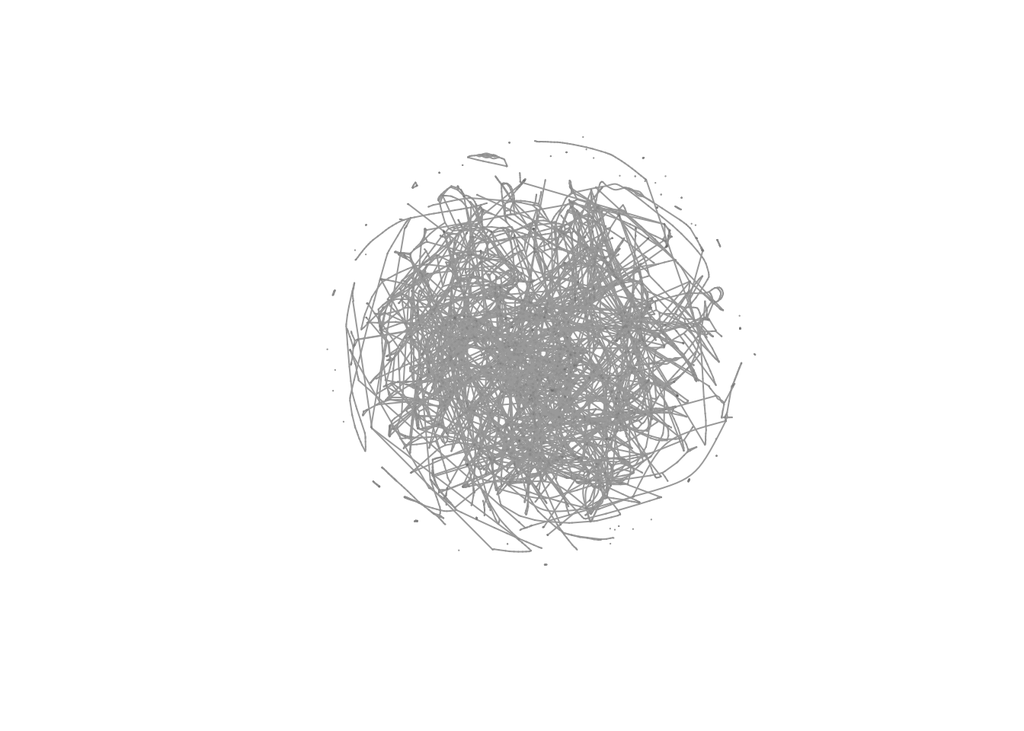

```r
plot(G_all,vertex.label=NA,vertex.size=.01)
```

**This doesn’t look like London!!!** –> let us assign coordinates to the nodes

```r
coordsPoints=points[points$id%in%as.numeric(V(G_all)$name),]

matched=match(as.numeric(V(G_all)$name),coordsPoints[,1])
V(G_all)$x=coordsPoints[matched,2]
V(G_all)$y=coordsPoints[matched,3]
```

Now if we plot it we see the streets! Can you recongise any of them? ;-)

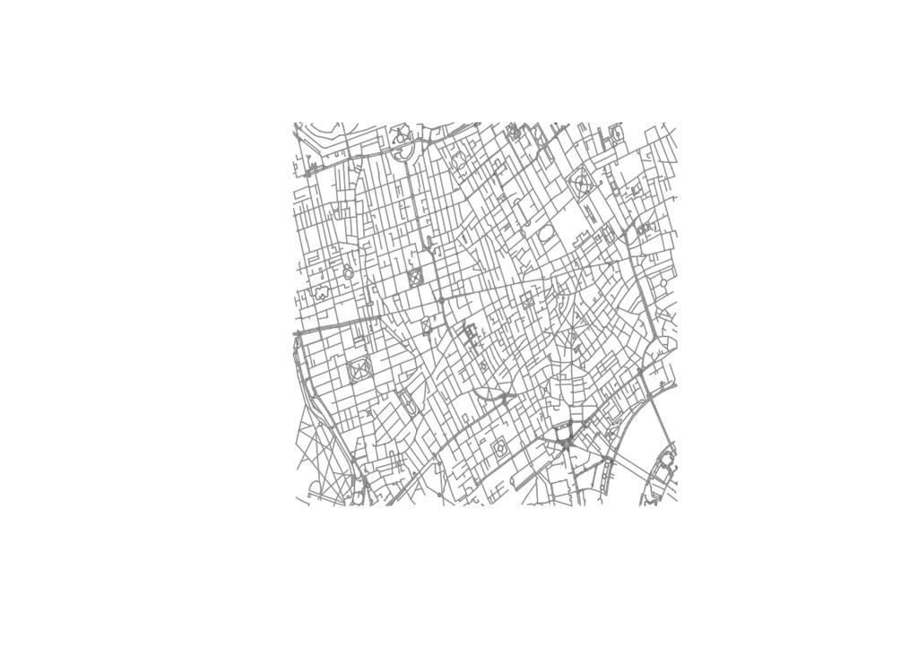

```r
plot(G_all,vertex.label=NA,vertex.size=.01)
```

There is a problem with the projection and this is easily solved projecting the points

In addition, let us see if the network is disconnected:

```r
components(G_all)$no
```

```
## [1] 55
```

```r
summary(components(G_all))
```

```
##            Length Class  Mode
## membership 10548  -none- numeric
## csize         55  -none- numeric
## no             1  -none- numeric
```

There are 55 disconnected components. This operation gives you the membership of each point, the cluster size of each component is obtained by typing $csize and the number of clusters $no.

```r
dist_sizes=components(G_all)$csize
dist_sizes[1:20]
```

```
##  [1] 10125     3     3     3     5    11     5     2     2     2     2
## [12]     2     2    11    18     7    13    13     3   105
```

```r
#Let us compute the size of largest component
largest_cpt=max(dist_sizes)
tot_nodes=length(V(G_all))
largest_cpt/tot_nodes
```

```
## [1] 0.9598976
```

Although there are disconnected bits, ~96% of the nodes belong to the largest component.

Some disconnected components are the outcome of the way we selected the area of interest, while some others might be a problem in the construction of the road networks: segments of streets disconnected, etc.

Let us take only the largest connected component

```r
gclust<-components(G_all, mode='weak')
largestConnectedComponent<-induced.subgraph(G_all, V(G_all)[which(gclust$membership == which.max(gclust$csize))])
G=largestConnectedComponent
all_weights=(E(G)$weight)
size_net=length(V(G))
```

And if we plot it again

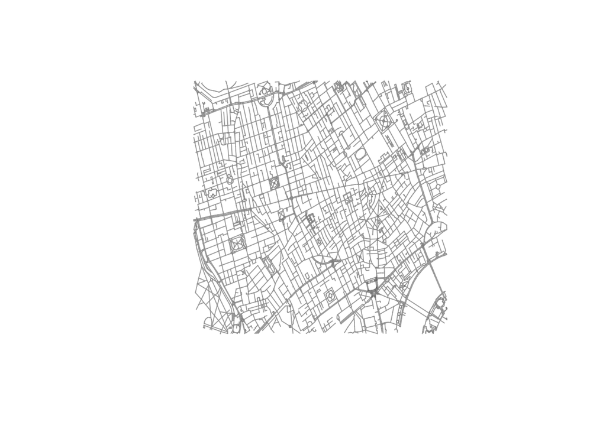

```r
plot(G,vertex.label=NA,vertex.size=.01)
```

## Centrality measures

Let us now compute a centrality measure on this network. Let us use for example closeness centrality

```r
closeness_G=closeness.estimate(G,cutoff=1000)
```

Note that we use “closeness.estimate” instead of “closeness”. In the documentation igraph.org: “estimate_closeness only considers paths of length cutoff or smaller, this can be run for larger graphs, as the running time is not quadratic (if cutoff is small). If cutoff is zero or negative then the function calculates the exact closeness scores.”

Let us define some nice colours for our nodes in the map

```r
getHSVColors=function(values,s=1,v=1){
  values=(values[values!=-1])
  vnorm=(values-min(values))/(max(values)-min(values))
  h=-2/3*vnorm+2/3
  colors=values
  colors[values!=-1]= hsv(h,s,v)
  colors[values==-1]= hsv(0,0,1)
  return (colors)
}
```

And let us plot it now

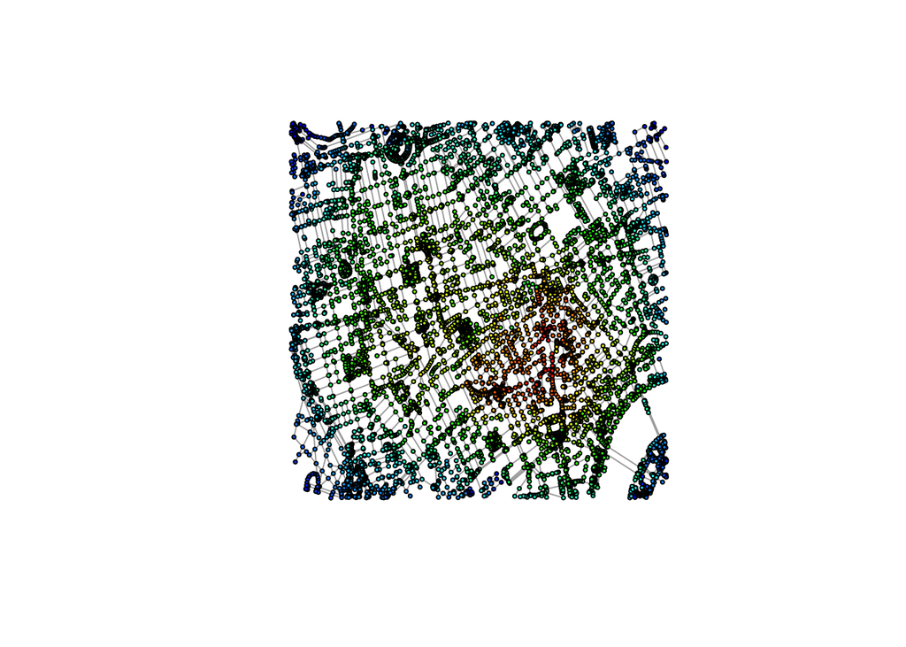

```r
plot(G,vertex.size=2,vertex.color=getHSVColors(closeness_G),vertex.label=NA)
```

And what about the degree distribution???

```r
degree_G=degree(G)
head(degree_G)
```

```
## 6226 6195 2758 2759 1292 2500
##    2    3    1    2    2    2
```

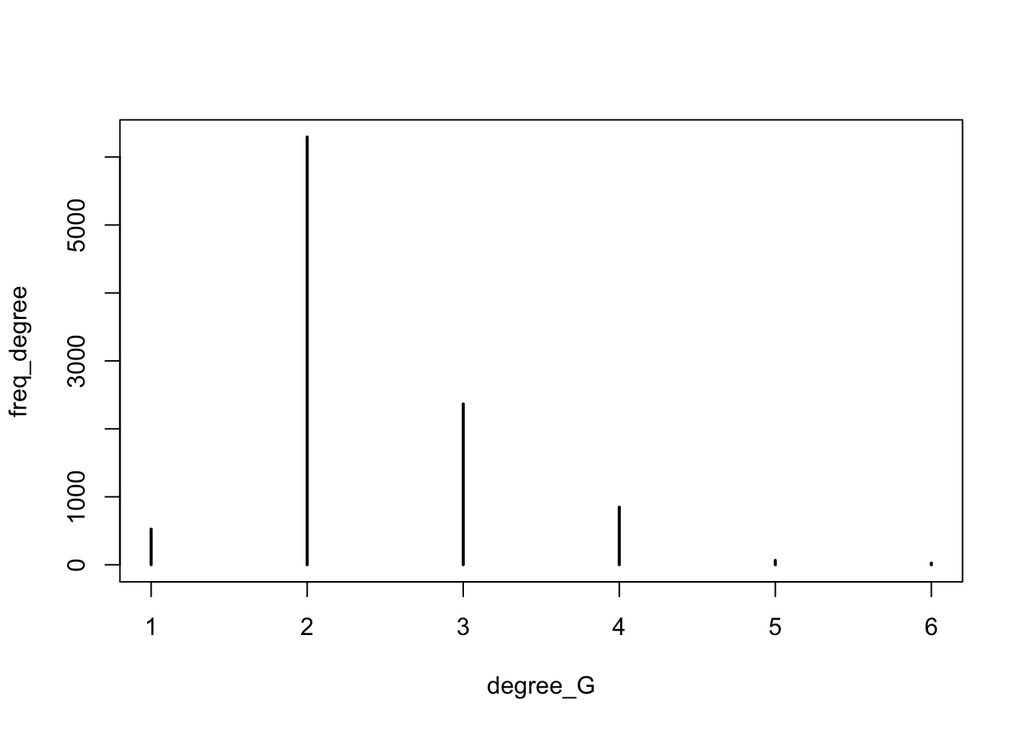

```r
freq_degree=table(degree_G)
plot(freq_degree)
```

Observe that most nodes have degree 2, as expected from this dataset. These biases need to be considered when transforming a dataset into a network. These artifical nodes do not represent the “real” morpholgy of the space.

# Cleaning the network

This code was created by Mateo Neira, MSc student at CASA 2016-2017.

Let us create small area to clean graph since this code is very lenghtly to run

create bounding box (West, North, East, South)

```r
delta_x=0.01
delta_y=0.008
T_West=min(V(G)$x)+delta_x
T_North= max(V(G)$y)-delta_y
T_East=max(V(G)$x)-delta_x
T_South=min(V(G)$y)+delta_y

bb_box<-c(T_West, T_North, T_East, T_South)
```

subset graph based on coordinates

```r
nodes_to_remove<-V(G)[which((V(G)$x < bb_box[1] | V(G)$x > bb_box[3]) | (V(G)$y > bb_box[2] | V(G)$y < bb_box[4]))]$name
g_s<-delete.vertices(G, nodes_to_remove)
```

This must have generated several disconnected components

```r
components(g_s)$no
```

```
## [1] 5
```

get largest connected component

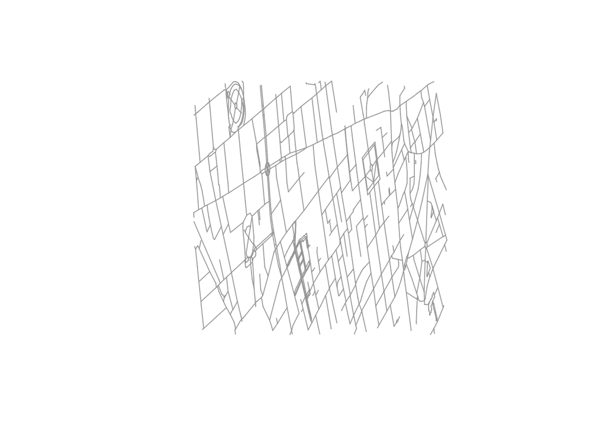

```r
gclust<-components(g_s, mode='weak')
largestConnectedComponent<-induced.subgraph(g_s, V(g_s)[which(gclust$membership == which.max(gclust$csize))])
G_s=largestConnectedComponent
plot(G_s,vertex.label=NA,vertex.size=.01)
```

get degree distribution of vertex

```r
V(G_s)$deg<-degree(G_s)
deg<-as.data.frame(cbind(V(G_s)$name,V(G_s)$deg))
deg2<-as.character(deg[which(deg$V2==2),1])
```

create for loop to remove degree 2 nodes and reconnect edges

```r
g_clean<-G_s
for(vrtx in c(1:length(deg2))){
  #print(deg2[vrtx])
  #get edge list to find which vertex degree two connect
  edge_list<-data.frame(cbind(get.edgelist(g_clean),E(g_clean)$weight))
  edge_list_2<-edge_list[which(edge_list$X1 %in% deg2[vrtx]),]
  edge_list_3<-edge_list[which(edge_list$X2 %in% deg2[vrtx]),]
  edge_list_3[,c("X1","X2")]<-edge_list_3[,c("X2","X1")]
  edge_list_2<-rbind(edge_list_2, edge_list_3)

  #add distances
  distance_list<-cbind(V=deg2[vrtx],D=sum(as.numeric(as.character(edge_list_2[,3]))))

  #edges
  edg<-c(as.character(edge_list_2[1,2]),as.character(edge_list_2[2,2]))

  #remove vertex
  g_clean<-delete.vertices(g_clean,deg2[vrtx])

  #add edges and distance
  g_clean<-add.edges(g_clean, edg, weight=sum(as.numeric(as.character(edge_list_2[,3]))))
}
```

Now let us compute a closeness centrality and plot the network

```r
closeness_g_clean=closeness.estimate(g_clean,cutoff=1000)
```

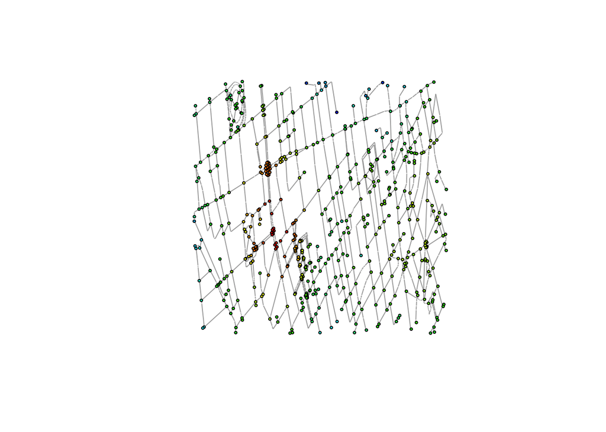

```r
plot(G_s, vertex.shape = 'none', vertex.label=NA, vertex.size = 1)
plot(g_clean,vertex.size=2,vertex.color=getHSVColors(closeness_g_clean),vertex.label=NA, add=TRUE, edge.color = NA)
```

Note that we cheated in the plot, in the sense that when removing nodes of degree 2 we also removed the streets that form “elbows”. In order to have then the right morphology, you will see that we plotted the network before cleaning without the vertices “G_s”, and then we put on top the vertices of the clean one “g_clean”.

Let us now look at the degree and verify that the cleaning took place as expected

```r
degree_g_clean=degree(g_clean)
head(degree_g_clean)
```

```
## 1607 5914 7124 1658 7125 1629
##    1    1    3    3    4    3
```

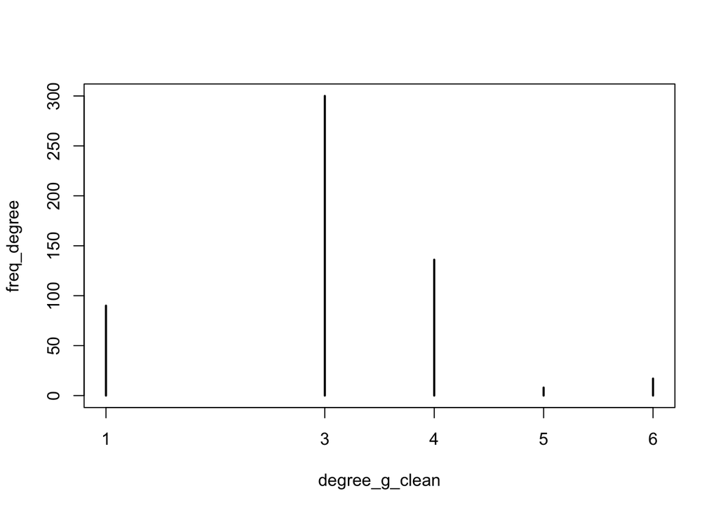

```r
freq_degree=table(degree_g_clean)
plot(freq_degree)
```

As expected, all the nodes of degree 2 have been removed.